# ValorGanado 23

límite de 3 operarios y línea base sin recursos

# Enunciado

Considere el proyecto cuyo cuadro de prelaciones, duración (semanas), operarios necesarios y presupuesto (BAC, k€) de cada actividad se adjunta; el coste se reparte uniformemente en cada actividad. La línea base se preparó con el calendario más temprano, sin mirar los recursos, pero la empresa dispone como máximo de **3 operarios** por semana: las actividades se ejecutan con el algoritmo de asignación (cada una empieza en cuanto puede), sin que nadie trabaje más lento de lo previsto. El coste real coincide con el presupuesto.

1. Calcule la línea base (duración y PV semana a semana) y el calendario real con el límite de operarios.

2. Calcule EV, SPI y la duración prevista T/SPI semana a semana. ¿Desde qué semana cae el SPI por debajo de 1 y qué actividad es la primera en esperar?

3. En la semana 10 (mitad de la línea base) ¿qué duración prevé el SPI? Compárela con la duración real. ¿Qué previsión es la acertada y por qué?

4. ¿Qué debería haber hecho el equipo al preparar la línea base? Calcule el SPI semana a semana con la línea base que respeta el límite de operarios y explique la diferencia.

Tabla 1: Datos del enunciado

| activity | predecessor | duration | operarios | BAC |
| --- | --- | --- | --- | --- |
| A | --- | 4 | 3 | 175 |
| B | --- | 2 | 1 | 175 |
| C | A,B | 3 | 2 | 175 |
| D | C | 6 | 1 | 100 |
| E | D | 5 | 1 | 125 |
| F | C | 5 | 2 | 50 |
| G | C | 8 | 2 | 150 |
| H | E,F | 1 | 2 | 125 |
| I | E,F,G | 3 | 2 | 150 |

# Resolución

**Notación** (siglas del PMBOK): BAC (*budget at completion*), presupuesto total del proyecto; PV (*planned value*), valor planificado: presupuesto del trabajo que, según el plan, debía estar hecho en la fecha de control; EV (*earned value*), valor ganado: presupuesto del trabajo realmente hecho; AC (*actual cost*), coste real de ese trabajo. Con ellos: CV = EV − AC (*cost variance*), variación del coste; SV = EV − PV (*schedule variance*), variación del plazo; CPI = EV / AC (*cost performance index*), índice de rendimiento del coste; SPI = EV / PV (*schedule performance index*), índice de rendimiento del plazo. Una variación negativa o un índice menor que 1 indica sobrecoste (CV, CPI) o retraso (SV, SPI).

## Apartado 1

1. Calcule la línea base (duración y PV semana a semana) y el calendario real con el límite de operarios.

Cálculo de los tiempos mínimos y máximos de los nodos del grafo Roy paso a paso. El primer paso muestra el grafo resuelto; a partir del siguiente se calcula desde el principio (avance con los botones):

[figure not shown]

paso 0 de 24

[figure not shown]

Figura 1: Grafo Roy de la línea base (sin recursos) con el camino crítico

Tabla 2: Calendario de la línea base (inicios más tempranos, sin mirar los operarios)

[figure not shown]

ninguna celda (0 de 72)

[figure not shown]

Haz clic en un número de la tabla para ver cómo se calcula.

👆 **Interactivo:** haz clic en cualquier celda de la tabla para ver cómo se calcula (otro clic la deselecciona), o usa los botones y las flechas del teclado.

| Actividad | Duración | Inicio más temprano | Fin más temprano | Inicio más tardío | Fin más tardío | H total | H libre | H independiente |
| --- | --- | --- | --- | --- | --- | --- | --- | --- |
| A | 4 | 0 | 4 | 0 | 4 | 0 | 0 | 0 |
| B | 2 | 0 | 2 | 2 | 4 | 2 | 2 | 2 |
| C | 3 | 4 | 7 | 4 | 7 | 0 | 0 | 0 |
| D | 6 | 7 | 13 | 7 | 13 | 0 | 0 | 0 |
| E | 5 | 13 | 18 | 13 | 18 | 0 | 0 | 0 |
| F | 5 | 7 | 12 | 13 | 18 | 6 | 6 | 6 |
| G | 8 | 7 | 15 | 10 | 18 | 3 | 3 | 3 |
| H | 1 | 18 | 19 | 20 | 21 | 2 | 2 | 2 |
| I | 3 | 18 | 21 | 18 | 21 | 0 | 0 | 0 |

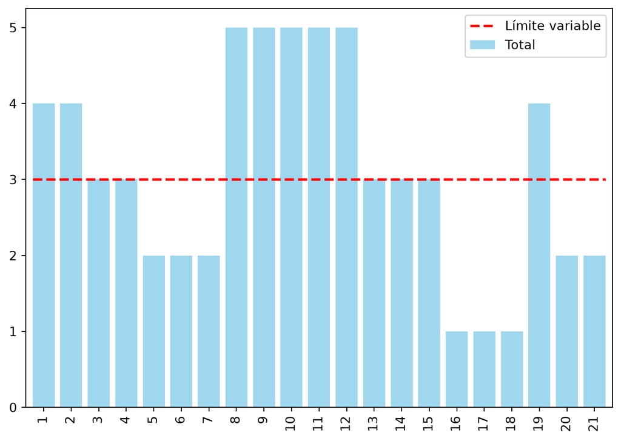

Figura 2: Carga de operarios de la línea base frente al límite

La ejecución real sigue el algoritmo de asignación: semana a semana, cada actividad disponible (predecesoras terminadas) empieza si caben sus operarios durante toda su duración; si no, espera. Traza semana a semana y Gantt resultante (filas 💤: esperas):

Periodo 1. Empiezan: [‘A’]. Esperan: [‘B (operarios)’]

Periodo 2. Empiezan: []. Esperan: [‘B (operarios)’]

Periodo 3. Empiezan: []. Esperan: [‘B (operarios)’]

Periodo 4. Empiezan: []. Esperan: [‘B (operarios)’]

Periodo 5. Empiezan: [‘B’]. Esperan: []

Periodo 7. Empiezan: [‘C’]. Esperan: []

Periodo 10. Empiezan: [‘D’, ‘G’]. Esperan: [‘F (operarios)’]

Periodo 11. Empiezan: []. Esperan: [‘F (operarios)’]

Periodo 12. Empiezan: []. Esperan: [‘F (operarios)’]

Periodo 13. Empiezan: []. Esperan: [‘F (operarios)’]

Periodo 14. Empiezan: []. Esperan: [‘F (operarios)’]

Periodo 15. Empiezan: []. Esperan: [‘F (operarios)’]

Periodo 16. Empiezan: [‘E’]. Esperan: [‘F (operarios)’]

Periodo 17. Empiezan: []. Esperan: [‘F (operarios)’]

Periodo 18. Empiezan: [‘F’]. Esperan: []

Periodo 23. Empiezan: [‘I’]. Esperan: [‘H (operarios)’]

Periodo 24. Empiezan: []. Esperan: [‘H (operarios)’]

Periodo 25. Empiezan: []. Esperan: [‘H (operarios)’]

Periodo 26. Empiezan: [‘H’]. Esperan: []

[figure not shown]

Figura 3: Gantt de la ejecución real con el límite de operarios

Tabla 3: Inicio de cada actividad en la línea base y en la ejecución real

|  | A | B | C | D | E | F | G | H | I |
| --- | --- | --- | --- | --- | --- | --- | --- | --- | --- |
| inicio línea base | 0 | 0 | 4 | 7 | 13 | 7 | 7 | 18 | 18 |
| inicio real | 0 | 4 | 6 | 9 | 15 | 17 | 9 | 25 | 22 |
| fin real | 4 | 6 | 9 | 15 | 20 | 22 | 17 | 26 | 25 |
| espera (semanas) | 0 | 4 | 0 | 0 | 0 | 8 | 0 | 3 | 0 |

El PV de cada semana es la suma, sobre las actividades, del BAC por la fracción planificada transcurrida (línea base); el EV, lo mismo con el calendario real (nadie trabaja más despacio, así que la fracción ejecutada es la real del calendario con recursos).

**Respuesta:** la línea base dura 21 semanas (calendario más temprano, tabla del calendario) y su PV semana a semana es la columna PV de la tabla del apartado 2; con 3 operarios el calendario real (inicios de la tabla anterior) dura 26 semanas, 5 más.

## Apartado 2

2. Calcule EV, SPI y la duración prevista T/SPI semana a semana. ¿Desde qué semana cae el SPI por debajo de 1 y qué actividad es la primera en esperar?

Semana a semana: SPI = EV / PV y duración prevista = T / SPI, con T la duración de la línea base.

Tabla 4: PV, EV, SPI y duración prevista semana a semana

| periodo | PV | EV | SPI | duración prevista |
| --- | --- | --- | --- | --- |
| 0 | 0.000 | 0.000 | NaN | NaN |
| 1 | 131.250 | 43.750 | 0.333 | 63.000 |
| 2 | 262.500 | 87.500 | 0.333 | 63.000 |
| 3 | 306.250 | 131.250 | 0.429 | 49.000 |
| 4 | 350.000 | 175.000 | 0.500 | 42.000 |
| 5 | 408.333 | 262.500 | 0.643 | 32.667 |
| 6 | 466.667 | 350.000 | 0.750 | 28.000 |
| 7 | 525.000 | 408.333 | 0.778 | 27.000 |
| 8 | 570.417 | 466.667 | 0.818 | 25.669 |
| 9 | 615.833 | 525.000 | 0.853 | 24.633 |
| 10 | 661.250 | 560.417 | 0.848 | 24.778 |
| 11 | 706.667 | 595.833 | 0.843 | 24.906 |
| 12 | 752.083 | 631.250 | 0.839 | 25.020 |
| 13 | 787.500 | 666.667 | 0.847 | 24.806 |
| 14 | 831.250 | 702.083 | 0.845 | 24.864 |
| 15 | 875.000 | 737.500 | 0.843 | 24.915 |
| 16 | 900.000 | 781.250 | 0.868 | 24.192 |
| 17 | 925.000 | 825.000 | 0.892 | 23.545 |
| 18 | 950.000 | 860.000 | 0.905 | 23.198 |
| 19 | 1125.000 | 895.000 | 0.796 | 26.397 |
| 20 | 1175.000 | 930.000 | 0.791 | 26.532 |
| 21 | 1225.000 | 940.000 | 0.767 | 27.367 |
| 22 | 1225.000 | 950.000 | 0.776 | 27.079 |
| 23 | 1225.000 | 1000.000 | 0.816 | 25.725 |
| 24 | 1225.000 | 1050.000 | 0.857 | 24.500 |
| 25 | 1225.000 | 1100.000 | 0.898 | 23.386 |
| 26 | 1225.000 | 1225.000 | 1.000 | 21.000 |

En la semana 1: SPI = EV / PV = 43.8 / 131.2 = 0.333 y T / SPI = 21 / 0.333 = 63.0 semanas. La actividad B debía empezar en la semana 1 según la línea base, pero no caben su 1 operario y espera (periodo 1 de la traza): su parte del PV se planificó y no se gana.

**Respuesta:** el SPI cae por debajo de 1 en la semana 1; la primera actividad que espera es B (periodo 1).

## Apartado 3

3. En la semana 10 (mitad de la línea base) ¿qué duración prevé el SPI? Compárela con la duración real. ¿Qué previsión es la acertada y por qué?

En la semana 10: SPI = EV / PV = 560.4 / 661.2 = 0.848; duración prevista T / SPI = 21 / 0.848 = **24.8** semanas, frente a una duración real de **26** semanas (diferencia -1.2). T/SPI supone que el ritmo relativo de la semana de control se mantiene hasta el final; aquí quedan esperas por venir que el SPI de esta semana todavía no refleja, así que subestima el retraso.

**Respuesta:** la previsión acertada es la del calendario con recursos (26 semanas), que conoce exactamente cuándo podrá empezar cada actividad; T/SPI (24.8) es solo una extrapolación.

## Apartado 4

4. ¿Qué debería haber hecho el equipo al preparar la línea base? Calcule el SPI semana a semana con la línea base que respeta el límite de operarios y explique la diferencia.

| periodo | PV | EV | PV con recursos | SPI con línea base realista |
| --- | --- | --- | --- | --- |
| 0 | 0.000 | 0.000 | 0.000 | NaN |
| 1 | 131.250 | 43.750 | 43.750 | 1.0 |
| 2 | 262.500 | 87.500 | 87.500 | 1.0 |
| 3 | 306.250 | 131.250 | 131.250 | 1.0 |
| 4 | 350.000 | 175.000 | 175.000 | 1.0 |
| 5 | 408.333 | 262.500 | 262.500 | 1.0 |
| 6 | 466.667 | 350.000 | 350.000 | 1.0 |
| 7 | 525.000 | 408.333 | 408.333 | 1.0 |
| 8 | 570.417 | 466.667 | 466.667 | 1.0 |
| 9 | 615.833 | 525.000 | 525.000 | 1.0 |
| 10 | 661.250 | 560.417 | 560.417 | 1.0 |
| 11 | 706.667 | 595.833 | 595.833 | 1.0 |
| 12 | 752.083 | 631.250 | 631.250 | 1.0 |
| 13 | 787.500 | 666.667 | 666.667 | 1.0 |
| 14 | 831.250 | 702.083 | 702.083 | 1.0 |
| 15 | 875.000 | 737.500 | 737.500 | 1.0 |
| 16 | 900.000 | 781.250 | 781.250 | 1.0 |
| 17 | 925.000 | 825.000 | 825.000 | 1.0 |
| 18 | 950.000 | 860.000 | 860.000 | 1.0 |
| 19 | 1125.000 | 895.000 | 895.000 | 1.0 |
| 20 | 1175.000 | 930.000 | 930.000 | 1.0 |
| 21 | 1225.000 | 940.000 | 940.000 | 1.0 |
| 22 | 1225.000 | 950.000 | 950.000 | 1.0 |
| 23 | 1225.000 | 1000.000 | 1000.000 | 1.0 |
| 24 | 1225.000 | 1050.000 | 1050.000 | 1.0 |
| 25 | 1225.000 | 1100.000 | 1100.000 | 1.0 |
| 26 | 1225.000 | 1225.000 | 1225.000 | 1.0 |

Como nadie trabaja más despacio de lo previsto, la línea base que respeta el límite de operarios (calendario de la asignación, 26 semanas) planifica exactamente lo que luego se gana: su PV coincide con el EV de cada semana y el SPI = EV / PV = 1 en todas. **Respuesta:** el equipo debería haber preparado la línea base con la asignación de recursos (3 operarios), comprometiendo 26 semanas en lugar de 21. Los problemas de recursos se detectan al planificar, no al controlar: un SPI < 1 desde la primera espera es síntoma de una línea base irrealista, no de un equipo lento.